# AN INTRODUCTION TO DATABASE SYSTEMS

by Date C.

Examples are given in PosgreSQL.

```python
from postgres_connector import *

print("Your default database is \"%s\"." % MyQuery().dbname)
```

```
Your default database is "date_db".
```

# PART II The relational model

Three principal aspects of data:

- data structure - chapters 5 and 6,
- data manipulation - chapters 7 and 8,
- data integrity - chapter 9.

Relational model can be regarded as itself as a small branch of mathematics - it evolves all the time, as mathematics do.

# 5. Types

**Type** (or **domain**) is a set of values:

- `INTEGER` is a set of all integers in $[-2^{31}, 2^{31} - 1]$,
- `CHAR` is a set of all character strings, etc.

Types can be:

- built-in, i.e. system-defined,
- user-defined.

**Operators** are the set of operations that can be made on the data type, like +, -, /, etc. for integers.

## 5.3 Types vs Representations

Types are *model* issues, while representations are *implementation* issue - physical representations must be hidden from the end user. This is very important aspect of *data independence*.

### Scalar vs Nonscalar Types

**Nonscalar** type is a type whose values are explicitly defined to have a set of user-visible, directly accessible components.

**Scalar** type is a type that is not nonscalar.

*ChatGPT*:  
In the relational model, scalar and non-scalar types refer to the classification of data types based on their properties and behavior within the database.

1. **Scalar Types:**
   - Scalar types represent single values, meaning they cannot be divided further into component parts.
   - Examples of scalar types include integers, floating-point numbers, characters, strings, dates, and Boolean values.
   - Scalar types typically represent atomic values that can be manipulated directly in computations or comparisons.
   - They are used to store individual data values in database columns.
2. **Non-Scalar Types:**
   - Non-scalar types represent values that can contain multiple components or elements.
   - These types include collections, arrays, structures, and other composite data structures.
   - Unlike scalar types, non-scalar types can be decomposed into smaller parts, each of which may have its own data type.
   - Non-scalar types are useful for storing complex data structures that cannot be represented by a single scalar value.
   - Examples of non-scalar types in relational databases include arrays, JSON objects, XML documents, and user-defined types.

In summary, scalar types represent single atomic values, while non-scalar types represent complex data structures composed of multiple components. Both types are important for modeling and storing data in relational databases, with each serving different purposes and accommodating different kinds of data.

### Possible Representation, Selectors, THE_operators

**Possible representation** (POSSREP) is just the given type we have chosen for given attribute, like `INTEGER`, while we could choose `REAL` or `BIGINT`, for example.

**Selectors** allow the user to specify or select a value of the type in question by supplying a value for each component of the possible representation.

**THE_operators** allow the user to access the corresponding possible-representation components of values of the type in question.

```
TYPE POINT
    POSSREP CARTESIAN (X RATIONAL, Y RATIONAL)
    POSSREP POLAR (R RATIONAL, PHI RATIONAL);

CARTESIAN (5.0, 2.5)  /* selects the point with x and y */

THE_X (P) /* denotes the x coordinate of the point in */
          /* P, where P is a variable of type POINT */
```

**Literals** are the selector invocations (but not all selector invocations are literals - a selector invocation is a literal if and only if all of its arguments are literals in turn).

## 5.4 `TYPE` and `DROP TYPE`

This is how you can define your own types based on the built-in types, so you actually only give the *name* by which the set of values can be referenced:

```
<type def> ::= TYPE <type name> <possrep def list> ;

<possrep def> ::= POSSREP [ <possrep name> ]
                        { <possrep component def commalist>
                                [ <possrep constraint def> ] }

<possrep component def> ::= [ possrep component name ] <type name>

<possrep constraint def> ::= CONSTRAINT <bool exp>
```

`DROP TYPE` actually does not drop the values, but only the name that was introduced by the `TYPE` statement:

```
DROP TYPE <type name>;
```

## 5.5 Operators

**Read-only** (they return values) vs **update** (or mutators, do not return anything, must be explicitly `CALL`ed) operators.

**THE_pseudovariable** is an invocation of a THE_operator in a target position (on the left side of an assignment):

```
THE_X ( P ) := - THE_X ( P ) ;
```

The SQL is a strong typed language. The total collection of types for a given database will be a **closed set** - that is, the type of the result of every valid expression will be a type that is known to the system.

## 5.6 Type Generators

**Type generators** return a type, instead of a scalar, like this:

```
char s[12];
```

we get the array of integers (`char` in C is just an integer of one byte) by invocation of the array type generator and it returns a specific array type, so this array type is **generated type**.

Synonims of the type generators are:

- type constructors,
- parametrized types,
- polymorphic types,
- type templates,
- generic types.

We regard generated types as system-defined types specifically, since they are obtained by invoking a system-defined type generator.

Any given type generator will also have a set of

- generic constraints and
- operators associated with it

(generic in the sense that the constraints and operators in question will apply to every specific type obtained via invocation of the type generator in question).

Two type generators that are of particular importance in the relational world are:

- `TUPLE`, and
- `RELATION`.

## 5.7 SQL Facilities

Built-in types can be divided into 10 disjoint categories:

- boolean,
- bit string,
- binary,
- character string,
- numeric,
- date,
- time,
- timestamp,
- year/month interval,
- day/time interval.

Type checking is performed on the basis of these 10 categories (on assignment and comparison operations, in particular). The types within these categories can be converted from one to another. If you assign a value of `CHAR(n1)` to a variable `CHAR(n2)`, then the value of `n1` length will be either truncated, or padded to match the length of `n2`.

User-defined types can be:

- distinct (one value) - `CREATE TYPE <type name> AS <representation> FINAL;`
- structured (many values) - `CREATE TYPE <representation> NOT FINAL;` where `representation` is `<attribute definition comma list>`.

**Routines** is an SQL term for operators, and there are three kinds:

- functions (read-only),
- procedures (update),
- methods (are like functions but have different syntax).

### Structured types

The comparison operators are specified by means of a separate `CREATE ORDERING` statement. If a given structured type has no associated "ordering" then no comparisons at all, not even equality comparisons, can be performed on values of that type - a state of affairs with far-reaching consequences, as you might imagine.

### Type Generators

SQL term is **type constructors**:

- `ROW`,
- `ARRAY`,
- `REF`.

```
CREATE TABLE customer
    (id CHAR(3),
     address ROW (street CHAR(50).
                  city CHAR(25),
                  state CHAR(2),
                  zip CHAR(5))
    PRIMARY KEY (id)) ;

SELECT cx.id
    FROM customer AS cx
    WHERE cx.address.state = 'CA' ;

INSERT INTO customer (id, address)
    VALUES ('666', ROW ('1600 Pennsylvania Ave.',
                       'Washington', 'D.C.', '20500')) ;
```

```
CREATE TABLE item_sales
    (id CHAR(5),
     sales INTEGER ARRAY [12],
     PRIMARY KEY (id)) ;
```

Types generated by means of `ARRAY` are always one-dimensional; the specified element type (`INTEGER` in the example) can be anything except for another `ARRAY` type.

The subscription starts with 1, not with 0.

```
SELECT id
    FROM item_sales
    WHERE sales[3] > 10 ;

INSERT INTO item_sales (id, sales)
    VALUES ('X4320', ARRAY [0, 0, 0, 0, 0, 0, 0, 0, 0, 0, 0, 0, 0]) ;

UPDATE item_sales
    SET sales[3] = 10
    WHERE id = 'Z0564' ;
```

Comparison operators are defined for both `ARRAY` and `ROW` type constructors.

If there is `a INTEGER ARRAY [n]`, then `CARDINALITY(a)` returns the value `n`.

# 6. Relations

- relational types, values, variables,
- tuples (as a relation building block) types, values, variables.

## 6.2 Tuples

- a collection of types $T_i$ where $i = 1, 2, ..., n$, not necessarily all distinct,
- a tuple value (**tuple** for short) on those types $t$ is a set of ordered triples of the form $<A_i,T_i,v_i>$, where
  - $A_i$ is an **attribute name**,
  - $T_i$ is a **type name**, and
  - $v_i$ is a **value** of type $T_i$, and
- The value $n$ is the **degree** of arity of $t$.
- The ordered triple $<A_i,T_i,v_i>$ is a **component** of $t$.
- The ordered pair $<A_i,T_i>$ is an **attribute** of $t$, and it is uniquely identified by the attribute name $A_i$ (attribute names $A_i$ and $A_j$ are the same only if $i = j$).
- The value $v_i$ is the **attribute value** for attribute $A_i$ of $t$.
- The type $T_i$ is the corresponding **attribute type**. The complete set of attributes is the **heading** of $t$.
- The **tuple type** of $t$ is determined by the heading of $t$, and the heading and that tuple type both have the same attributes (and hence the same attribute names and types) and the same degree as $t$ does. The tuple type name is precisely:

$$ \text {TUPLE}\ \{\ A_1 T_1, A_2 T_2,\ ..., A_n T_n\ \} $$

A sample tuple:

| major_p# : P# | minor_p# : P# | quantity : QTY |
| --- | --- | --- |
| P2 | P4 | 7 |

- The attribute names: `major_p#` , `minor_p#` , `quantity`,
- the corresponding type names: `P#`, `P#`, `QTY`,
- the corresponding values: `P#('P2')`, `P#('P4')`, and `QTY(7)`,
- the degree is 3,
- the heading: `| major_p# : P# | minor_p# : P# | quantity : QTY |`
- the type: `TUPLE { major_p# P#, minor_p# P#, quantity QTY }`

In informal context it is common to omit the type names from a tuple heading, showing just the attribute names:

| major_p# | minor_p# | quantity |
| --- | --- | --- |
| P2 | P4 | 7 |

### Properties of tuples

- Every tuple contains exactly one value (of the appropriate type) for each of its attributes.
- There is no left-to-right ordering to the components of a tuple because a tuple is a set and the sets are not ordered in math (tuples in math are ordered, though, because it is not a set in math - VR).
- Every subset of a tuple is a tuple, and every subset of a heading is a heading.

### N-tuples

A tuple of degree $n$ is n-ary tuple:

- a tuple of degree zero is nullary tuple,
- of degree 1 - unary tuple,
- of degree 2 - binary tuple,
- of degree n - n-ary tuple.

Sometimes they are called 0-tuples, 4-tuples, etc.

### The TUPLE Type Generator

A TUPLE type generator invocation takes the general form:

```
TUPLE { <attribute commalist> }
```

where each `<attribute>` consists of `<attribute name>` followed by a `<type name>`:

```
VAR ADDR TUPLE ( street CHAR,
                 city CHAR,
                 state CHAR,
                 zip CHAR
) ;
```

It is a generated type.

Every tuple type has an associated **tuple selector** operator:

```
TUPLE { street '1600 Pennsylvania Ave.', city 'Washington', state 'DC', zip '20500'}
```

This expression can be assigned to the tuple variable `ADDR` or tested for equality with another tuple of the same type.

In order for two tuples to be of the same type, it is necessary and sufficient that they have the same attributes.

### Operators on Tuples

The semantics of tuple equality in detail, all of the following are defined in terms of it:

- Essentially all of the operators of the relational algebra (Ch. 7),
- candidate keys (Ch. 9),
- foreign keys (Ch. 9),
- functional and other dependencies (Ch. 11 - 13).

Precise definition:

- **Tuple equality**: Tuples $t_1$ and $t_2$ are equal (i.e. $t_1 = t_2$ is true) if and only if
  - they have the same attributes $A_1, A_2, ..., A_n$ and
  - for all $i$ where $i = 1, 2, ..., n$ the value $v_1$ of $A_i$ in $t_1$ is equal to the value $v_2$ of $A_i$ in $t_2$.
- Tuples $t_1$ and $t_2$ are duplicates of each other if and only if they are equal (i.e. they are the very same tuple).

All 0-tuples are duplicates of one another. Thus there is *the* 0-tuple, not *a* 0-tuple.

The comparison operators $<$ and $>$ do not apply to tuples, i.e. tuple types are not "ordinal types".

#### `WRAP` and `UNWRAP`

```
TUPLE ( name NAME, addr TUPLE { street CHAR, city CHAR,
                                state CHAR, zip CHAR } ) ;

TUPLE (name NAME, street CHAR, city CHAR,
       state CHAR, zip CHAR) ;

naddr2 WRAP { street, city, state, zip } AS addr

naddr1 UNWRAP addr
```

which is this assignment:

```
naddr2 := naddr1 UNWRAP addr ;
```

## 6.3 Relation Types

A **relation value** (relation, $r$) consists of *heading* and *body*, where:

- the **heading** of $r$ is a *tuple heading* as defined in 6.2:
  - and it has the same attributes, attribute names, types, and degree as heading does,
  - it also called: relation schema, scheme, intension;
- the **body** of $r$ is a set of tuples, all having that same heading:
  - the cardinality is the cardinality of $r$,
  - it also called: extension.

The **relation type name** is:

```
RELATION { A1 T1, A2 T2, ... An Tn }
```

| major_p# : P# | minor_p# : P# | quantity : QTY |
| --- | --- | --- |
| P1 | P2 | 5 |
| P2 | P4 | 7 |
| P3 | P5 | 4 |

But the type names are usually ommited:

| major_p# | minor_p# | quantity |
| --- | --- | --- |
| P1 | P2 | 5 |
| P2 | P4 | 7 |
| P3 | P5 | 4 |

Strictly speaking, a relation does not contain tuples - it contains a body, and that body in turn contains tuples. Informally, however, it is convenient to talk as if relations contained tuples directly.

Also, note:

- every subset of a heading is a heading,
- every subset of a body is a body.

*ChatGPT:*  
The term "relation" in the context of relational algebra was introduced by Edgar F. Codd, the inventor of the relational model for database management. The choice of the word "relation" was likely influenced by its meaning in set theory#References), where a relation is a set of ordered pairs. In the context of databases, a relation can be seen as a set of tuples, each representing an ordered collection of attribute values. So, the term "relation" emphasizes the idea of a mathematical relationship between entities represented by tuples in a table-like structure.

## 6.4 Relation values

Within any given relation:

- Every tuple contains exactly one value (of the appropriate type) for each attribute.
- There is no left-to-right ordering to the attributes (relations in math do have ordering).
- There is no top-to-botton ordering to the tuples.
- There are no duplicate tuples.

Let's consider this example:

```python
q = "TABLE s;"
MyQuery().psql(q)
```

```
 id | sname | status |  city
----+-------+--------+--------
  1 | Smith |     20 | London
  2 | Jones |     10 | Paris
  3 | Blake |     30 | Paris
  4 | Clark |     20 | London
  5 | Adams |     30 | Athens
(5 rows)
```

1. **Relations are normalized**:
- $1NF$ - a relation, that satisfies the property that every tuple in every relation contains exactly one value for each of its attributes
2. **Attributes are Unordered, left to right**:
- attributes are always referenced by name, never by position - as a result, the scope for errors and obscure programming is reduced;
- thus, this is the same relation as shown above:

```python
MyQuery().psql('SELECT sname, status, id, city FROM s;')
```

```
 sname | status | id |  city
-------+--------+----+--------
 Smith |     20 |  1 | London
 Jones |     10 |  2 | Paris
 Blake |     30 |  3 | Paris
 Clark |     20 |  4 | London
 Adams |     30 |  5 | Athens
(5 rows)
```

3. **Tuples are Unordered, top to bottom**:
- this is because the body is a set, and sets in math have no ordering;
- thus, there is no concept of positional addressing;
- because there is one and only one way to represent information in the given model, we need one and only one set of operators to deal with it, so the complexity to learn is reduced (see Codd's "Information Principle");
- this is the same relation as shown above:

```python
MyQuery().psql("SELECT sname, status, id, city FROM s ORDER BY sname;")
```

```
 sname | status | id |  city
-------+--------+----+--------
 Adams |     30 |  5 | Athens
 Blake |     30 |  3 | Paris
 Clark |     20 |  4 | London
 Jones |     10 |  2 | Paris
 Smith |     20 |  1 | London
(5 rows)
```

Of course, some notion of top-to-bottom tuple ordering and left-to-right attribute ordering is required in the interface between the database and a host language such as C or Python (see Operations Involving Cursors). But it is the host language, not the relational model, and such notions are part of the environment in which the relational implementation resides.

4. **There are no duplicate values**:
- the body of the relation is a set, and sets in math do not have duplicate elements;
- this is one of the distinctions between a table and a relation: relations *never* contain duplicate elements.

### Relations vs. Tables

For details, see p. 151.

A relation is an abstract kind of object, and a table is a concrete picture, typically on paper, of such an abstract object.

### Relation-Valued Attributes

Relation types can be used as the basis for defining attributes of relations, it other words, attributes can be **relation-valued**:

- relations with attributes whose values are relations in turn, i.e.
- relations that have other relations nested inside themselves.

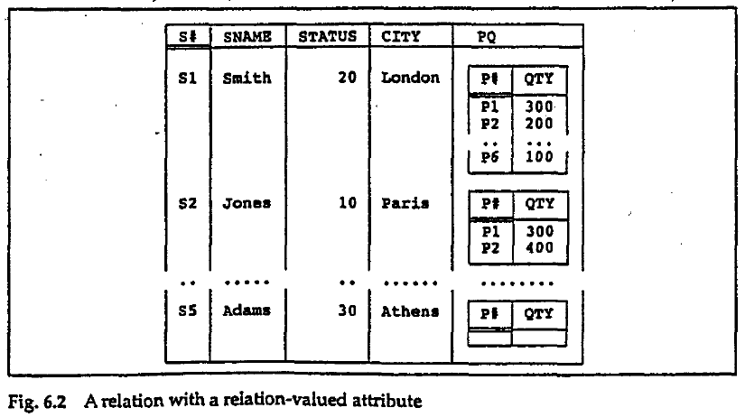

NOT TURE ANYMORE:

Attribute `PQ` is relation-valued, and the supplier `S5` has an empty set value of `PQ`.

> **Repeating group** - a column that contains several values in each row.  
> id|repeating group column -|- 1|1, 2 2|2, 3 ...|...

In the relational model *all column values are atomic*, i.e. repeating groups are not allowed.

We can see that relation-valued attributes do not follow this former rule.

### Relations with no attributes

Since the empty set is certainly a set, a relation's heading can also be empty - an empty set of attributes.

Can a relation with no attributes contain tuples? Yes, it can, but only one tuple and it is the 0-tuple. As a consequence, there are precisely two relations of zero-degree:

- **TABLE_DEE** - a relation with one 0-tuple, and
- **TABLE_DUM** - a relation that contains no tuples at all.

Why are these relations so important?

- they play a role in the relational algebra,
- `DEE` means `true` and `DUM` means `false`.

### Operators on Relations

```
<relation exp> <relation comp op> <relation exp>
```

`<relation comp op>` must be one of the following:

| sign | meaning |
| --- | --- |
| $=$ | equals |
| $\neq$ | not equals |
| $\in$ | element of |
| $\subseteq$ | subset of |
| $\subset$ | proper subset of |
| $\supseteq$ | superset of |
| $\supset$ | proper superset of |

Then we allow a `<relation comp>` to appear wherever a `<bool exp>` is expected, for example, in `WHERE` claus:

1. $s\ \{\ city\ \} = p\ \{\ city\ \}$
- Meaning: Is the projection of suppliers over `city` equal to the projection of parts over `city`?
2. $s\ \{\ s.id\ \} \subset sp\ \{\ s.id\ \}$
- Meaning: Are there any suppliers who supply no parts at all?

## 6.5 Relation Variables

- base relvars
- views

See also 3.7 Base relvars and views

### Base Relvar Definition

```
VAR <relvar name> BASE <relation type>
                  <candidate key def list>
                [ <foreing key def list> ] ;

<relation type> := REALATION { <attribute commalist } ;
```

Example:

```
VAR s BASE RELATION
    { s#    S#,
      sname NAME,
      status INTEGER,
      city  CHAR }
    PRIMARY KEY { s# } ;

VAR sp BASE RELATION
    { s#    S#,
      p#    P#,
      qty   QTY }
    PRIMARY KEY { s#, p# }
    FOREIGN KEY { s# } REFERENCES s
    FOREING KEY { p# } REFERENCES P ;
```

1. These base relvars have (relation) types as follows:

```
RELATION { s# S#, sname NAME, status INTEGER, city CHAR }

RELATION { s# S#, p# P#, qty QTY}
```

2. Everything said to relation values is applicable to relvars (heading, body, degree, etc.).
3. All possible values of a relvar have the same heading.
4. When a base relvat is defined, it is given an initial value, that is the empty relation of the applicable type.
5. Each base relvar definition includes exactly one `<candidate key def>` of the form:

```
PRIMARY KEY { <attribute name commalist> }
```

7. Defining a new relvar causes the system to make entries in the catalog to describe this relvar.
8. There is a means available for specifying **default values** for attributes of base relvars.

Drop relvar syntax:

```
DROP VAR <relvar name> ;
```

### Updating relvars

Relational assignment operations (`INSERT`, `DELETE`, `UPDATE`) are all **set-level** operations (by definition, `CURRENT` forms of `DELETE` and `UPDATE` in SQL are *tuple*-level, i.e. row-level, and are contraindicated).

Each update operation is the relvar reassignment operation:

```
DELETE s WHERE city = 'Paris' ;

--is really is
s := s WHERE NOT (city = 'Paris') ;
```

We update a *set* of tuples, not a tuple, because tuple, as relation value (i.e. relation), is a value and it cannot be updated by definition. We can delete one tuple and insert another tuple, and, when we update a set of tuples (even if we replace only one-tuple set, i.e. a set of cardinality one), in fact we replace one set of tuples with another and assign this new set to the relvar.

> Whenever Postgres reads a row it needs to answer a query from disk, Postgres reads the entire page the row is on. When Postgres writes to a row on a page, it writes a whole new copy of the entire page to disk at one time - PG4E

### Relvars and their Interpretation

1. The heading of the relvar can be regarded as the **predicate**.
2. The tuples appearing in that relvar at any given time can be regarded as **true propositions**, obtained from the predicate by substituting arguments of the appropriate type for the parameters of that predicate ("*instantiating the predicate*").

**Closed World Assumption/Interpretation**:

- if an otherwise valid tuple - that is, one that conforms to the relvar heading - does *not* appear in the body of the relvar, then we can assume the corresponding proposition is false.

In other words,

> the body of the relvar at any given time contains *all* and *only* the tuples that correspond to true propositions at that time.

See also Ch. 9.

## 6.6 SQL Facilities

SQL does not support many concepts of the relational algebra described above. Some are listed below, for more info read the chapter.

### Rows

- there are no tuples in SQL, **rows** instead,
- rows are left-to-right ordered,
- within a given row, the component values are identified by their ordinal position, they are called:
  - "column values" if the row is immediately contained in a table,
  - "field values", otherwise.

### Table Types

- there no "relations" in SQL, "**tables** instead", where body is "a bag of rows", or also called **multiset**,
- tables have no order but can contain duplicates,
- tables are left-to-right ordered,
- SQL does not use terms *heading* and *body*,
- it supports an operator for testing whether the given row is in the given table:

```
<row value constructor> IN <table exp>
```

where `<row value constructor` is basically a tuple selector.

### Table Values and Table Variables

- SQL does not support table-valued attributes, but it includes [JSONB](https://www.postgresql.org/docs/16/datatype-json.html) in PostgreSQL - VR

#### `CREATE TABLE`

```
CREATE TABLE <base_table_name>
        (<base_table_element_commalist>);
```

Each `<base_table_element>` is either:

- a `<column_definition>`
  - takes the form of `<column_name> <type_name> [ <default_spec ]`

or

- a `<constraint>`.

#### `DROP TABLE`

```
DROP TABLE <base_table_name> <behaviour>;
```

where `<behaviour` is either:

- `RESTRICT` (the drop op will fail if the table in use somewhere else), or
- `CASCADE` (the drop will always succeed).

#### `ALTER TABLE`

- a new column can be added,
- a new default can be defined for an existing column,
- an existing column default can be deleted,
- an existing column can be deleted,
- a new integrity constraint can be specified,
- an existing integrity constraint can be deleted.

Example:

```
ALTER TABLE s ADD COLUMN discount INTEGER DEFAULT -1 ;
```

For other ops, like `INSERT`, `DELETE`, `UPDATE` statements see Ch. 4.

### Structured Types

This means, the attributes of the table that we can access using `.`:

```
SELECT s.status FROM s;
```

See Ch. 26 for details.

# 7. Relational Algebra

The **relational algebra** is a collection of operators that take relations as their operands and return a relation as their result.

The original algebra Codd outlined in 1969-1970 had 8 operators, two groups for each:

- union, intersection, difference, and Cartesian product,
- the special relational operators: restrict (select), project, join, and divide.

But many other operators were added since then. In this chapter we will discuss only these 8 operators as the basis for a variety of algebraic ideas.

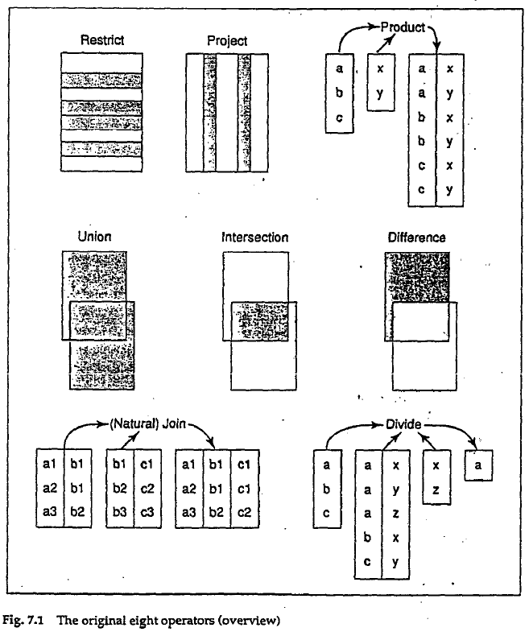

## 7.1 Closure Revisited

**Closure** is the relational property of having the output from any given relational operation to be another relation.

This allows us to nest the relational expresions in other relational expressions.

We need to define the relational operations in such a way as to guarantee that every operation produces a result with a proper relation type, in particular, with proper attribute names (this algebra fact is overlooked by SQL).

Therefore we need a set of **relation type inference rules** built into the algebra, such that:

- if we know the type(s) of the input relation(s) for any given relational operation, we can infer the type of the output from that operation.

### `RENAME`

- rename attributes within a specified relation.

The operator takes a given relation and returns another that is identical to the given one except that one of its attributes has a different name, for example this expression (this is not a command or statement, thus it can be nested into other expressions):

```
RENAME city AS scity;
```

This expression yields a relation with the same heading and body as the relation that is the current value of relvar S, except that the `city` attribute is named `scity` instead.

> Note: The `RENAME` expression does not change the relvar in the database, it is just an expression.

Thus, the relational algebra, unlike SQL, does not need dot-qualified attribute names such as `s.id`.

## 7.2 The Original Algebra: Syntax

Notation for relational operations

| symbol | meaning |
| --- | --- |
| $\sigma$ | restriction ("selection") |
| $\pi$ | projection |
| $\cap$ | intersection |
| $\phi$ | join |

## 7.3 The Original Algebra: Semantics

All the operations must return the same type to preserve the closure principle.

### Union

> Given two relations $a$ and $b$ of the same type, the **union** of those two relations, $a\ \text{UNION}\ b$, is a relation of the same type, with body consisting of all tuples $t$ such that $t$ is equal to (i.e., is a duplicate of) some tuple in $a$ or $b$ or both.

### Intersect

> Given two relations $a$ and $b$ of the same type, the **intersection** of those two relations, $a\ \text{INTERSECT}\ b$, is a relation of the same type, with body consisting of all tuples $t$ such that $t$ appears in both $a$ and $b$.

### Difference

> Given two relations $a$ and $b$ of the same type, the **difference** of those two relations, $a\ \text{MINUS}\ b$ (in that order), is a relation of the same type, with body consisting of all tuples $t$ such that $t$ appears in $a$ and not in $b$.

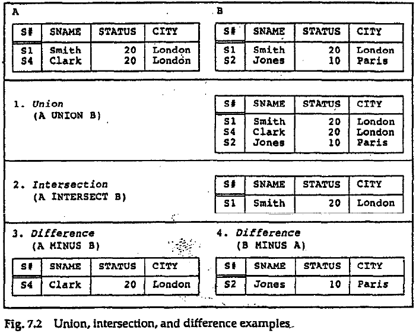

### Product

The relational version of Cartesian product is an *extended form* of the operation, in which each ordered pair of tuples is replaced with the single tuple that is the *union* of the two tuples in question (using "union" in its normal set theory sense, not its special relational set).

> The (relational) Cartesian product of two relations $a$ and $b$, $a\ \text{TIMES}\ b$, where $a$ and $b$ have no common attribute names, to be a relation with a heading that is the (set theory) union of a tuple appearing in $a$ and a tuple appearing in $b$.

Note, that

- the cardinality of the result is the product of the cardinalities, and
- the degree of the result is the sum of the degrees, of the input relations $a$ and $b$.

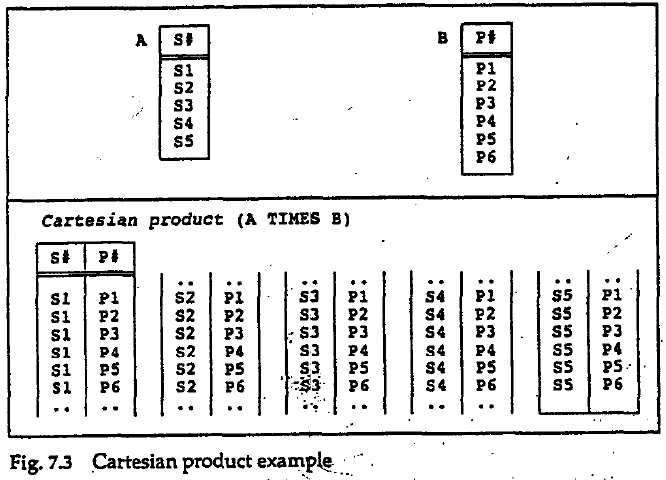

### Restrict

Let relation $a$ have attributes $X$ and $Y$ (and possibly others), and let $\theta$ be an operator - typically $=,\ \neq,\ >,\ <$ and so on - such that the boolean expression $X\ \theta\ Y$ is well-formed and, given particular values for $X$ and $Y$, evaluates to a truth value (`TRUE` or `FALSE`). Then the **$\theta$-restriction**, or just *restriction* for short, of relation $a$ on attributes $X$ and $Y$ (in that order): $$ a\ \ \text {WHERE}\ X\ \ \theta\ \ Y $$

is a relation with the same heading as $a$ and with body consisting of all tuples of $a$ such that the expression $X\ \theta\ Y$ evaluates to `TRUE` for the tuple in question.

Generalized definition:

> Let relation $a$ have attributes X, Y, ..., Z (and possibly others), and let $p$ be a truth-valued function whose parameters are, precisely, some subset of X, Y, ..., Z. Then the restriction of $a$ according to $p$: $$ a\ \ \text {WHERE}\ p $$ is a relation with the same heading as $a$ and with body consisting of all tuples of $a$ such that $p$ evaluates to `TRUE` for the tuple in question.

Points arising:

1. $p$ is a predicate.
2. We refer to this predicate as a **restriction condition**:
   - a simple restricion condition is one that can be evaluated for a given tuple $t$ without examining any tuple other than $t$ (subqueries are the example of opposite condition - VR).
3. The following equivalences are worthy of note:

```
a WHERE p1 OR p2 = (a WHERE p1) UNION (a WHERE p2)
a WHERE p1 AND p2 = (a WHERE p1) INTERSECT (a WHERE p2)
a WHERE NOT (p) = a MINUS (a WHERE p)
```

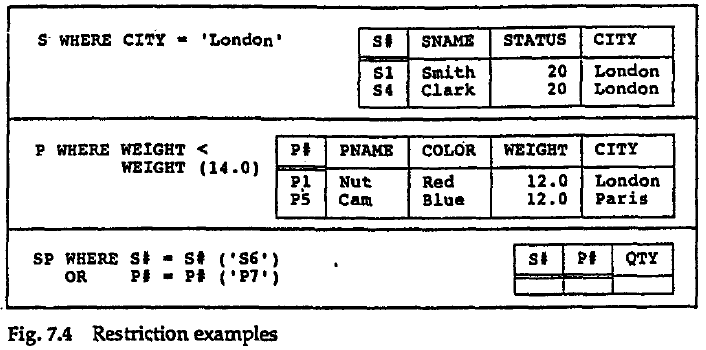

### Project

Let relation $a$ have attributes $(\ X,\ Y,\ ...,\ Z)$ (and possibly others). Then,

> the **projection** of relation $a$ on $(\ X,\ Y,\ ...,\ Z)$

> $$a\ \{\ X,\ Y,\ ...,\ Z\ \}$$

> is a relation with
> - A heading derived from the heading of $a$ by removing all attributes not mentioned in the set $(\ X,\ Y,\ ...,\ Z)$,
> - A body consisting of all tuples $(\ Xx,\ Yy,\ ...,\ Zz)$ such that a tuple appears in $a$ with $(\ X\ \text{value}\ x,\ Y\ \text{value}\ y,\ ...,\ Z\ \text{value}\ z)$.

The subset, thus, obtained by

- removing all attributes not mentioned in the specified commalist of attribute names, and then
- eliminating duplicate (sub)tuples from what is left.

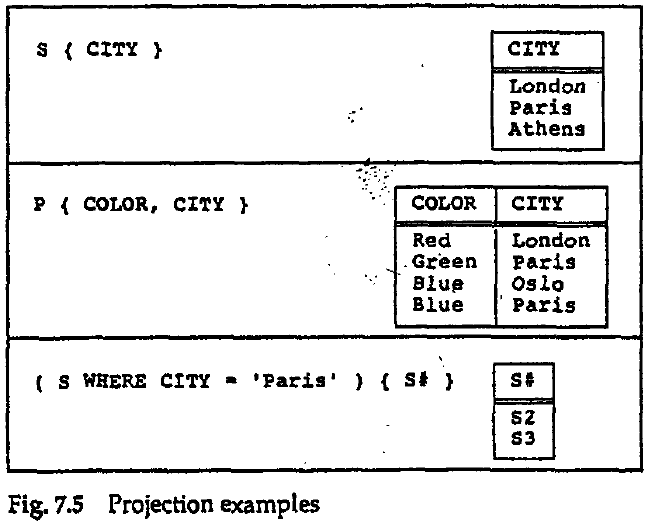

```python
MyQuery().psql("SELECT city FROM s;")
```

```
  city
--------
 London
 Paris
 Paris
 London
 Athens
(5 rows)
```

```python
MyQuery().psql("SELECT color, city FROM p;")
```

```
 color |  city
-------+--------
 Red   | London
 Green | Paris
 Blue  | Oslo
 Red   | London
 Blue  | Paris
 Red   | London
(6 rows)
```

```python
MyQuery().psql("SELECT color, city FROM p;")
```

```
 color |  city
-------+--------
 Red   | London
 Green | Paris
 Blue  | Oslo
 Red   | London
 Blue  | Paris
 Red   | London
(6 rows)
```

```python
MyQuery().psql("SELECT id FROM s WHERE city = 'Paris';", verbose=True)
```

```
psql -h localhost -p 5432 -U user1 -d date_db -c "SELECT id FROM s WHERE city = 'Paris';"

 id
----
  2
  3
(2 rows)
```

```python
MyQuery().psql("SELECT id, id, id FROM s;")
```

```
 id | id | id
----+----+----
  1 |  1 |  1
  2 |  2 |  2
  3 |  3 |  3
  4 |  4 |  4
  5 |  5 |  5
(5 rows)
```

### Join

#### Natural `join`

Join comes in several different varieties. The most important is **natural** join, and the unqualified *join* is almost always taken to mean the natural join specifically.

Let the relations $a$ and $b$ have attributes

```
X1, X2, ..., Xm, Y1, Y2, ..., Yn
```

and

```
Y1, Y2, ..., Yn, Z1, Z2, ..., Zp
```

respectively; that is, the $Y$ attributes $Y1, Y2, ..., Yn$ (only) are common to the two relations, the $X$ attributes $X1, X2, ..., Xm$ are the other attributes of $a$, and the $Z$ attributes $Z1, Z2, ..., Zp$ are the other attributes of $b$.

Now consider $(X1,\ X2,\ ...,\ Xm)$, $(Y1,\ Y2,\ ...,\ Yn)$, and $(Z1,\ Z2,\ ...,\ Zp)$ are three **composite** attributes $X$, $Y$, and $Z$, respectively. Then,

> the (natural) **join** of $a$ and $b$ - $$a\ \text{JOIN}\ b$$
> - is a relation with heading $(X,Y,Z)$ and body consisting of tuples (Xx, Yy, Zz) such that a tuple appears in $a$ with $X$ value $x$ and $Y$ value $y$ and a tuple appears in $b$ with $Y$ value $y$ and $Z$ value $z$.

> Note: Joins are not always between a foreign key and a matching primary (or candidate) key, even though such joins are a very common and important special case.

```python
print("Natural join 'S JOIN P'")
MyQuery().psql(
    """
    SELECT s.id AS s_id, sname, s.status, s.city,
            p.id AS p_id, pname, color, weight
        FROM s
        JOIN p on s.city = p.city
        ORDER BY s_id, weight;
    """)
```

```
Natural join 'S JOIN P'

 s_id | sname | status |  city  | p_id | pname | color | weight
------+-------+--------+--------+------+-------+-------+--------
    1 | Smith |     20 | London |    1 | Nut   | Red   |     12
    1 | Smith |     20 | London |    4 | Screw | Red   |     14
    1 | Smith |     20 | London |    6 | Cog   | Red   |     19
    2 | Jones |     10 | Paris  |    5 | Cam   | Blue  |     12
    2 | Jones |     10 | Paris  |    2 | Bolt  | Green |     17
    3 | Blake |     30 | Paris  |    5 | Cam   | Blue  |     12
    3 | Blake |     30 | Paris  |    2 | Bolt  | Green |     17
    4 | Clark |     20 | London |    1 | Nut   | Red   |     12
    4 | Clark |     20 | London |    4 | Screw | Red   |     14
    4 | Clark |     20 | London |    6 | Cog   | Red   |     19
(10 rows)
```

#### $\theta$-join

- join two relations on the basis of some comparison operator other than equality.
- Let relations $a$ and $b$ satisfy the requirements for Cartesian product (i.e., they have no attribute names in common);
- let $a$ have an attribute $X$ and let $b$ have an attribute $Y$, and
- let $X$, $Y$, $\theta$ satisfy the requirements for $\theta$-restriction.

Then,

> the $\theta$-join of relation $a$ on attribute $X$ with relation $b$ on attribute $X$ with relation $b$ on attribute $Y$ is defined to be the result of evaluating the expression:

$$ (\ \ a\ \text{TIMES}\ b\ )\ \text{WHERE}\ X\ \theta\ Y $$

In other words, it is a relation with the same heading as the Cartesian product of $a$ and $b$, and with a body consisting of the set of all tuples $t$ such that $t$ appears in that Cartesian product and the expression $X\ \theta\ Y$ evaluates to `TRUE` for that tuple $t$.

```
( ( S RENAME CITY AS SCITY ) TIMES
  ( P RENAME CITY AS PCITY ) )
WHERE SCITY > PCITY
```

```python
MyQuery().psql(
    """
    SELECT s.id AS s_id, sname, s.status, s.city AS scity,
            p.id AS p_id, pname, color, weight, p.city AS pcity
        FROM s
        CROSS JOIN p  --cartesian product
        WHERE s.city > p.city
        ORDER BY s_id;
    """
)
```

```
 s_id | sname | status | scity | p_id | pname | color | weight | pcity
------+-------+--------+-------+------+-------+-------+--------+--------
    2 | Jones |     10 | Paris |    1 | Nut   | Red   |     12 | London
    2 | Jones |     10 | Paris |    3 | Screw | Blue  |     17 | Oslo
    2 | Jones |     10 | Paris |    4 | Screw | Red   |     14 | London
    2 | Jones |     10 | Paris |    6 | Cog   | Red   |     19 | London
    3 | Blake |     30 | Paris |    6 | Cog   | Red   |     19 | London
    3 | Blake |     30 | Paris |    1 | Nut   | Red   |     12 | London
    3 | Blake |     30 | Paris |    4 | Screw | Red   |     14 | London
    3 | Blake |     30 | Paris |    3 | Screw | Blue  |     17 | Oslo
(8 rows)
```

If $\theta$ is '=', the $\theta$-join is called an **equijoin**.

The result of the equijoin must include two attributes with the property that the values of those two attributes are equal in every tuple in the relation. If one of those two attributes is projected away and the other renamed appropriately (if necessary), the result is the natural join!

### Divide

There are two types of **divide**:

- Small Divide,
- Great Divide.

Here we discuss the Small Divide and its particular limited form.

Let relations $a$ and $b$ have attributes:

```
X1, X2, ..., Xm
```

and

```
Y1, Y2, ..., Yn
```

respectively, where no attribute $X_i(i=1, 2, ..., m)$ has the same name as any attribute $Yj(j=1, 2, ..., n)$, and let the relation $c$ have attributes

```
X1, X2, ..., Xm, Y1, Y2, ..., Yn
```

(i.e., $c$ has a heading that is the union of the headings of $a$ and $b$).

Let us now regard `{ X1, X2, ..., Xm }` and `{ Y1, Y2, ..., Yn }` as *composite* attributes $X$ and $Y$, respectively. Then

> the division of $a$ by $b$ per $c$, where
> - $a$ is a diviend,
> - $b$ is a divisor, and
> - $c$ is the "mediator".

> $$a\ \text{DIVIDEBY}\ b\ \text{PER}\ c$$

> is a relation with
> - heading `{ X }` and
> - body consisting of all tuples `{ Xx }` appearing in $a$ such that a tuple `{ Xx, Yy }` appears in $c$ for *all* tuples `{ Yy }` appearing in $b$.

In other words, the result consists of those $X$ values from $a$ whose corresponding $Y$ values in $c$ include all values from $b$.

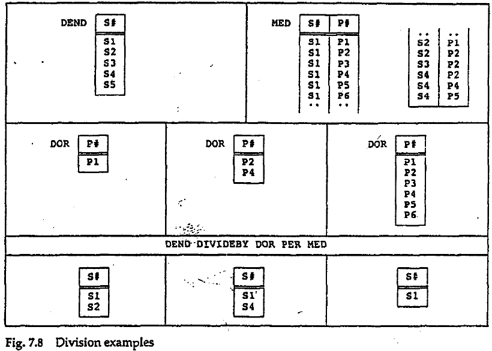

So, all `DOR` entries must appear for all `s_id` in `MED` (`AND` operation).

The queries of that general nature are often more readily expressed in terms of *relational comparisons*:

```
S WHERE ( ( SP RENAME S# AS X ) WHERE X = S# ) { P# } = P { P# }
```

and this is the divideby version:

```
S JOIN { S { S# } DIVIDEBY P { P# } PER SP { S#, P# } }
```

There is some doubt as to whether `DIVIDEBY` would ever have been defined if the relational model had included relational comparisons in the first place, but it did not.

# 8. Relational Calculus